# Reproducible Research Course Project 1

##Instructions

1. Code for reading in the dataset and/or processing the data
2. Histogram of the total number of steps taken each day
3. Mean and median number of steps taken each day
4. Time series plot of the average number of steps taken
5. The 5-minute interval that, on average, contains the maximum number of steps
6. Code to describe and show a strategy for imputing missing data
7. Histogram of the total number of steps taken each day after missing values are imputed
8. Panel plot comparing the average number of steps taken per 5-minute interval across weekdays and weekends
9. All of the R code needed to reproduce the results (numbers, plots, etc.) in the report

```r
knitr::opts_chunk$set(echo = TRUE)

##Preparing the Workspace
library("lattice")
library("data.table")
library("ggplot2")
library("dplyr")

# Specify Working Directory
#setwd("C:/Users/azizi/Desktop/Course Project 1")

# Specify URL where file is stored
#url <- "https://d396qusza40orc.cloudfront.net/repdata%2Fdata%2Factivity.zip"

# Specify destination where file should be saved
#destfile <- "C:/Users/azizi/Desktop/Course Project 1/repdata%2Fdata%2Factivity.zip"

# Apply download.file function in R
#download.file(url, destfile)

# Unzipping the file
#unzip(zipfile="C:/Users/azizi/Desktop/Course Project 1/repdata%2Fdata%2Factivity.zip")
```

##Loading and preprocessing the data

```r
activity <- read.csv("./activity.csv")
summary(activity)
```

```
##      steps            date              interval
##  Min.   :  0.00   Length:17568       Min.   :   0.0
##  1st Qu.:  0.00   Class :character   1st Qu.: 588.8
##  Median :  0.00   Mode  :character   Median :1177.5
##  Mean   : 37.38                      Mean   :1177.5
##  3rd Qu.: 12.00                      3rd Qu.:1766.2
##  Max.   :806.00                      Max.   :2355.0
##  NA's   :2304
```

##1. What is mean total number of steps taken per day?

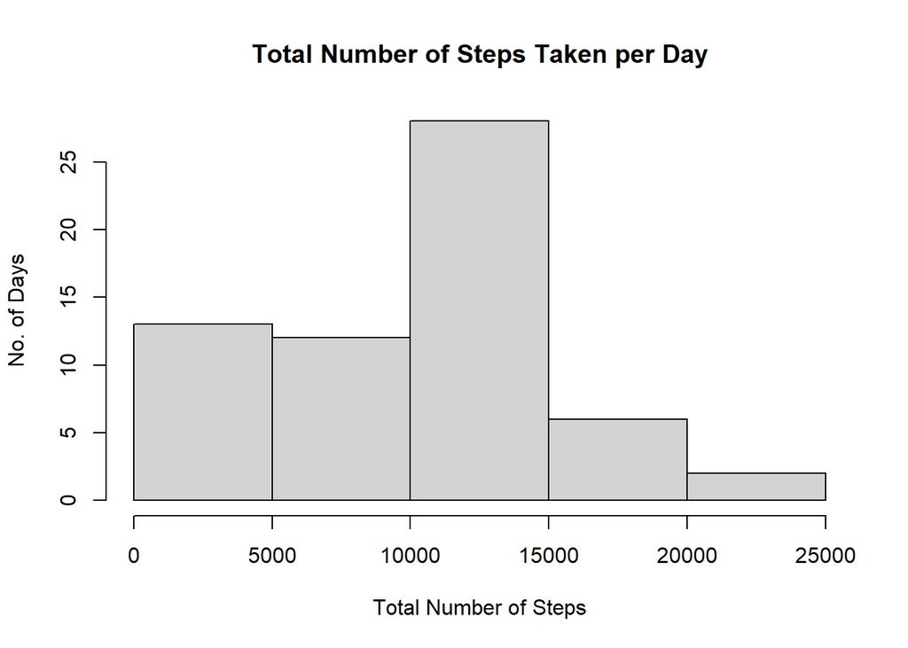

```r
totalSteps <- with(activity, aggregate(steps, by = list(date), sum, na.rm = TRUE))
colnames(totalSteps) <- c("date", "steps")

hist(totalSteps$steps, xlab="Total Number of Steps", ylab="No. of Days", main="Total Number of Steps Taken per Day")
```

#Mean of the total number of steps taken per day

```r
mean(totalSteps$steps)
```

```
## [1] 9354.23
```

#Median of the total number of steps taken per day

```r
median(totalSteps$steps)
```

```
## [1] 10395
```

##2. What is the average daily activity pattern?

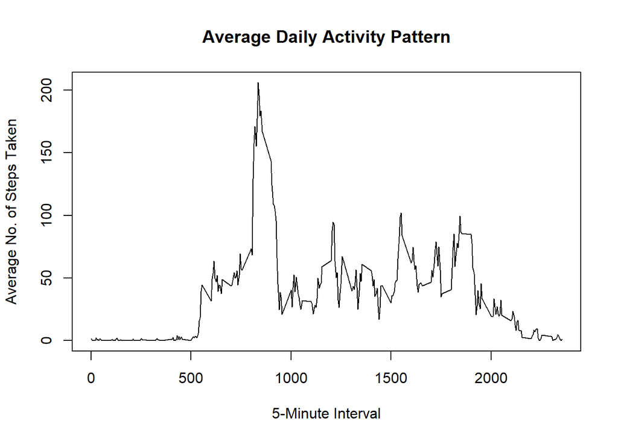

```r
pattern <- aggregate(activity$steps, by = list(activity$interval), mean, na.rm=TRUE)

colnames(pattern) <- c("interval", "mean")

plot(pattern$interval, pattern$mean, type = "l", xlab="5-Minute Interval", ylab="Average No. of Steps Taken", main="Average Daily Activity Pattern")
```

#Which 5-minute interval, on average across all the days in the dataset, contains the maximum number of steps?

```r
pattern[which.max(pattern[,2]),1]
```

```
## [1] 835
```

##3. Imputing missing values

#Total no. of missing values in the dataset

```r
sum(is.na(activity$steps))
```

```
## [1] 2304
```

#Imputed by using mean of the 5-minute interval and rechecking total no. of missing values after imputing

```r
imputed <- pattern$mean[match(activity$interval, pattern$interval)]

sum(is.na(imputed))
```

```
## [1] 0
```

#Histogram of the total number of steps taken each day after imputing

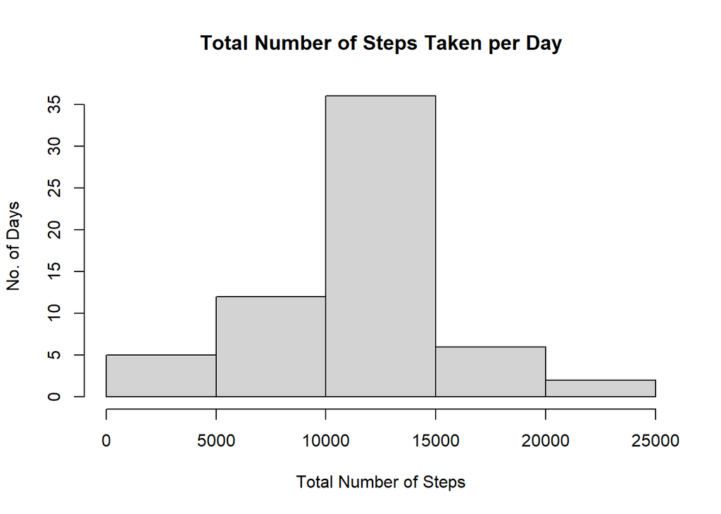

```r
imputed_5_min <- transform(activity, steps = ifelse(is.na(activity$steps), yes = imputed, no = activity$steps))
totalStepsNew <- aggregate(steps ~ date, imputed_5_min, sum)
colnames(totalStepsNew) <- c("date", "interval_steps")

hist(totalStepsNew$interval_steps, xlab="Total Number of Steps", ylab="No. of Days", main="Total Number of Steps Taken per Day")
```

#Mean of the total number of steps taken per day after imputing

```r
mean(totalStepsNew$interval_steps)
```

```
## [1] 10766.19
```

#Median of the total number of steps taken per day after imputing

```r
median(totalStepsNew$interval_steps)
```

```
## [1] 10766.19
```

#The difference values between the original datasets and the imputed datasets for mean & median

```r
difference_mean <- mean(totalStepsNew$interval_steps)  - mean(totalSteps$steps)
difference_median <- median(totalStepsNew$interval_steps) - median(totalSteps$steps)
```

#The difference values between the original datasets and the imputed datasets for mean is;

```r
print(difference_mean)
```

```
## [1] 1411.959
```

#and for median is;

```r
print(difference_median)
```

```
## [1] 371.1887
```

##4. Are there differences in activity patterns between weekdays and weekends?

#Creating a new factor variable in the dataset with two levels – “weekday” and “weekend”

```r
imputedNew<-imputed%>%
        mutate(dayType= ifelse(weekdays(imputed$date)=="Saturday" | weekdays(imputed$date)=="Sunday", "Weekend", "Weekday"))
head(imputedNew)
```

[output not shown]

#Making a panel plot containing a time series plot

```r
averageAll<-imputedNew %>% group_by(dayType, interval) %>% summarize(averageByDay=sum(steps))
```

[figure not shown]

```r
with(averageAll, xyplot(averageByDay ~ interval | dayType, type = "l"
      , xlab = "Intervals"
      , ylab = "Average Number of Steps"))
```